# Tugas Pertemuan 8

Ananda Putra Wijaya/G1401221111

2024-10-27

# Inisiasi Library

```r
library(ggplot2)
library(tidyverse)
library(tsibble)
library(tseries)
library(MASS)
library(readxl)
library(forecast)
library(TSA)
library(TTR)
library(aTSA)
library(graphics)
library(lmtest)
library(car)
library(portes)
library(plotly)
```

# Inisiasi Data

```r
mrt=read_xlsx("C:/Tugas/Semester 5/Metode Peramalan Deret Waktu/Minggu 8/Data Pertemuan 8.xlsx")
mrt=ts(mrt[,2], frequency = 7)
```

Data yang digunakan adalah data harian jumlah penumpang MRT Stasiun Dukuh Atas BNI City. Data dimulai dari periode 1 Januari 2023 sampai 16 Juli 2023, sebanyak 197 data. Data diambil dari laman SIASATI.

# Plot Data Penuh

## Time Series Plot

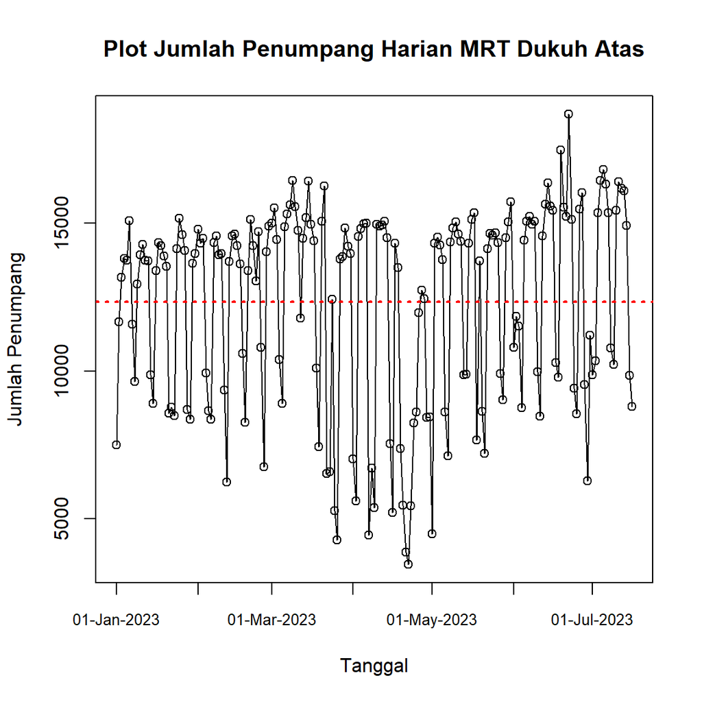

```r
tanggal <- seq(as.Date("2023-01-01"), as.Date("2023-07-16"), by = "day")
plot(tanggal, mrt, type = "l",
     main = "Plot Jumlah Penumpang Harian MRT Dukuh Atas",
     ylab = "Jumlah Penumpang",
     xlab = "Tanggal",
     xaxt = "n")
axis_dates <- seq(min(tanggal), max(tanggal), by = "1 months")
points(tanggal, mrt, pch = 1, cex = 1)
axis(1, at = axis_dates, labels = format(axis_dates, "%d-%b-%Y"), las = 1, cex.axis = 0.8)
abline(h = mean(mrt), col = "red", lwd = 2, lty = 3)
```

Dari plot *time series* di atas, dapat dilihat bahwa data penuh cenderung stasioner ragam dan rataan. Perlu dilakukan uji formal untuk menentukan kestasioneritasan data.

## Decompose Plot

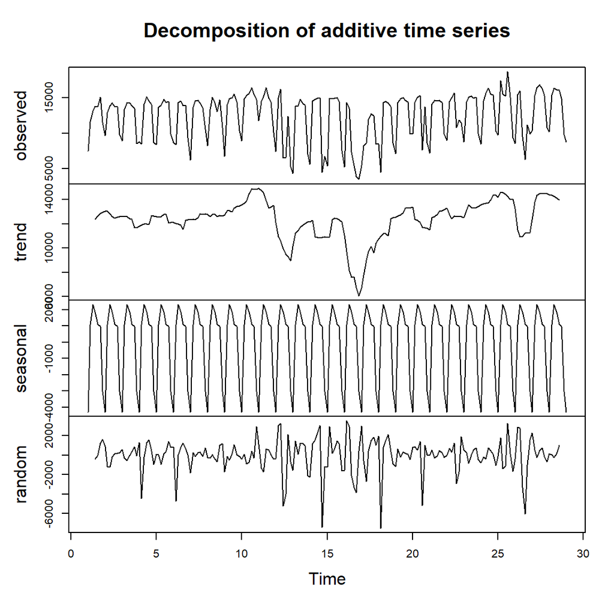

```r
plot(decompose(mrt))
```

Plot dekomposisi di atas menunjukkan bahwa data yang dipakai memiliki komponen musiman, dengan “Minggu” sebagai musimnya.

## Seasonal Plot

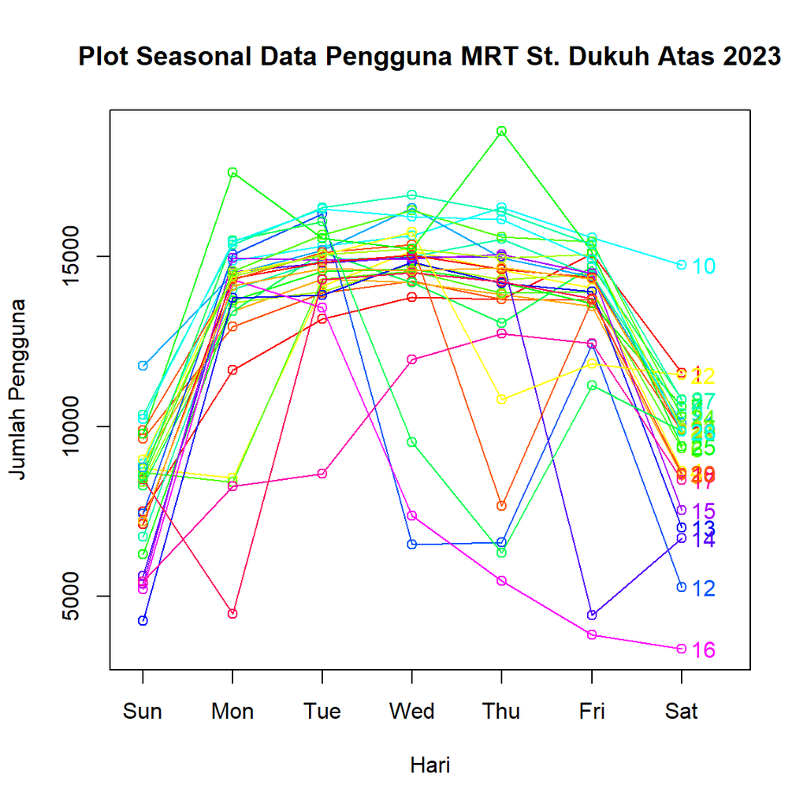

```r
seasonplot(mrt,7,main="Plot Seasonal Data Pengguna MRT St. Dukuh Atas 2023", ylab="Jumlah Pengguna", xlab ="Hari",
           year.labels = T, col=rainbow(18))
```

Berdasarkan *Seasonal Plot* di atas, dapat kita lihat bahwa hari kerja(*weekday*) merupakan hari tersibuk Stasiun MRT Dukuh Atas. Pada hari Sabtu dan Minggu(*weekend*), terdapat penurunan yang signifikan terhadap pengguna Stasiun MRT Dukuh Atas.

# Pembagian Data Latih dan Data Uji

```r
mrtlat=ts(mrt[1:152])
mrtlatts = subset(mrt, start=1, end=152)
mrtuji=ts(mrt[153:197])
mrtujits = subset(mrt, start=153, end = 197)
```

# Data Latih

## Plot Data Latih

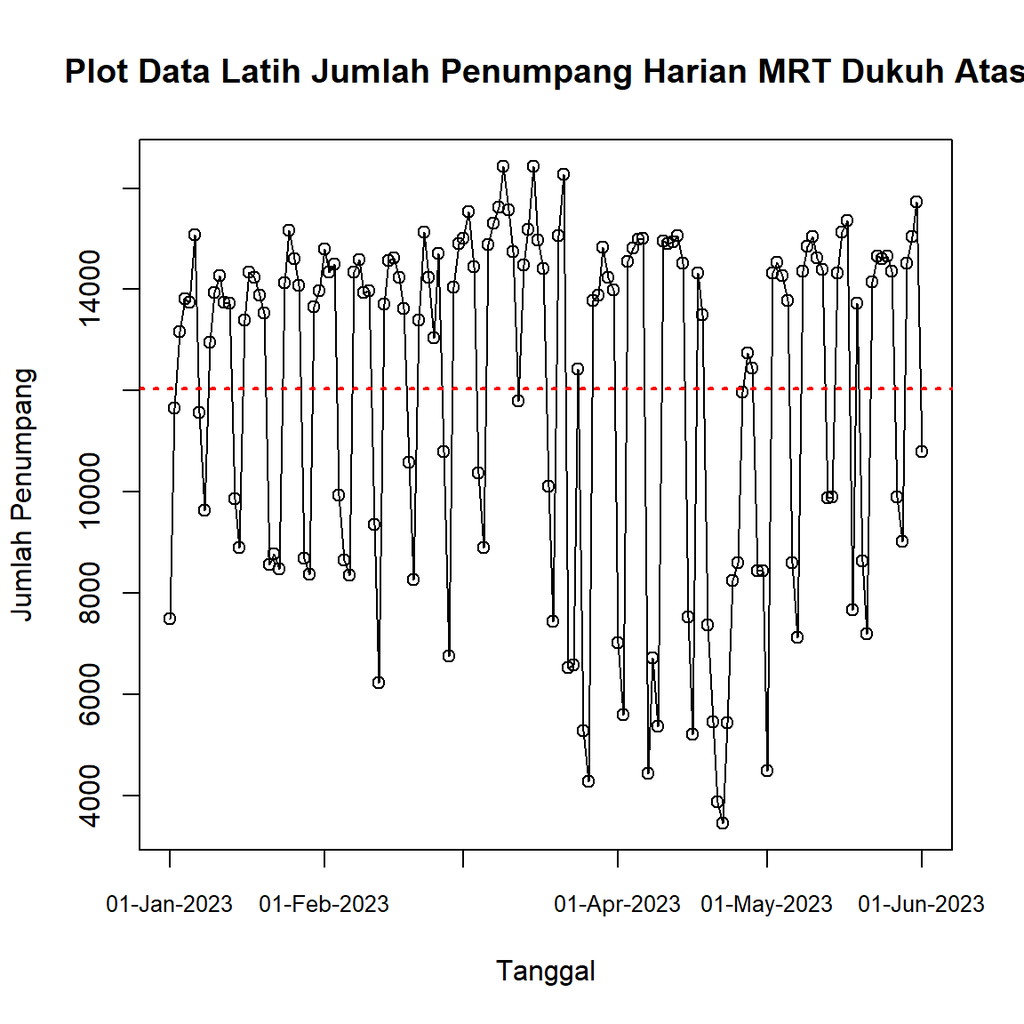

```r
tgllat <- seq(as.Date("2023-01-01"), as.Date("2023-06-1"), by = "day")
plot(tgllat, mrtlatts, type = "l",
     main = "Plot Data Latih Jumlah Penumpang Harian MRT Dukuh Atas",
     ylab = "Jumlah Penumpang",
     xlab = "Tanggal",
     xaxt = "n")
axis_dates <- seq(min(tgllat), max(tgllat), by = "1 months")
points(tgllat, mrtlatts, pch = 1, cex = 1)
axis(1, at = axis_dates, labels = format(axis_dates, "%d-%b-%Y"), las = 1, cex.axis = 0.8)
abline(h = mean(mrtlatts), col = "red", lwd = 2, lty = 3)
```

Plot data latih menunjukkan bahwa data latih tampak stasioner ragam dan rataan.

## Rataan

### ADF Test

```r
tseries::adf.test(mrtlatts)
```

```
##
##  Augmented Dickey-Fuller Test
##
## data:  mrtlatts
## Dickey-Fuller = -3.4116, Lag order = 5, p-value = 0.05526
## alternative hypothesis: stationary
```

$H_0$ : Data tidak stasioner dalam rataan

$H_1$ : Data stasioner dalam rataan

Dari uji ADF yang dilakukan, didapat nilai p sebesar 0.055, artinya tak tolak H0. Maka data latih tidak stasioner dalam rataan.

### ACF Plot

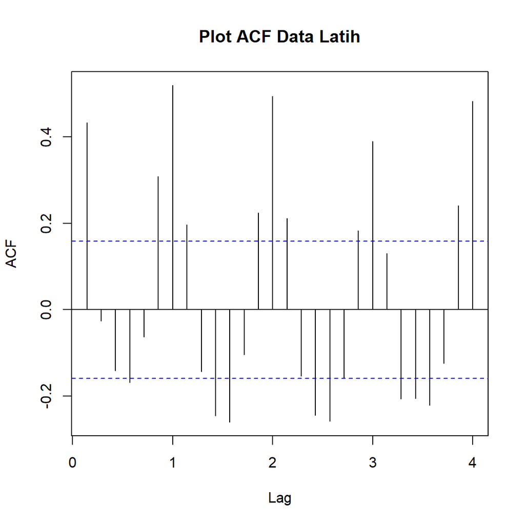

```r
acf0=acf(mrtlatts, lag.max = 28, xaxt="n", main="Plot ACF Data Latih")
axis(1, at=0:28, labels=0:28)
```

Dapat kita lihat bahwa komponen *seasonal* atau musiman pada data latih kita memiliki *lag* yang *tails of slowly*, sedangkan komponen non-*seasonal*nya *cuts of*. Maka kita dapat menyatakan bahwa komponen *seasonal* tidak stasioner dalam ragam, namun komponen non-*seasonal*nya stasioner dalam ragam.

## Ragam

```r
index <- seq(1:152)
bc1 = boxcox(mrtlatts~index, lambda = seq(-2,10,by=0.1))
```

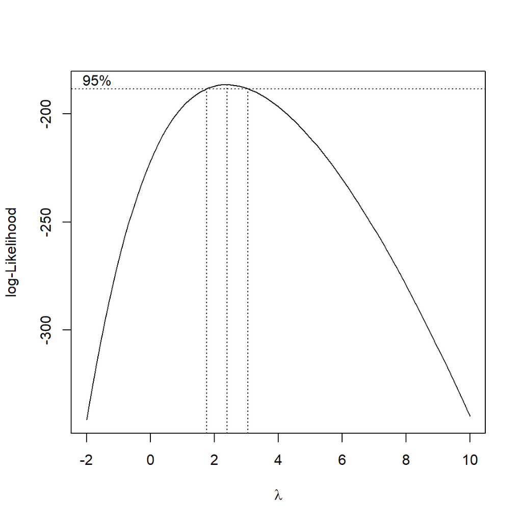

```r
optlambda <- bc1$x[which.max(bc1$y)]
optlambda
```

```
## [1] 2.4
```

```r
#SK
bc1$x[bc1$y > max(bc1$y) - 1/2 * qchisq(.95,1)]
```

```
##  [1] 1.8 1.9 2.0 2.1 2.2 2.3 2.4 2.5 2.6 2.7 2.8 2.9 3.0
```

Berdasarkan plot *Box-Cox* di atas, dapat kita lihat bahwa nilai 1 tidak masuk ke dalam selang kepercayaan 95%. Artinya data latih tidak stasioner dalam ragam.

# Penanganan Ragam

```r
mrtlattsbc=(mrtlatts^2-1)/2
tbc = boxcox(mrtlattsbc~index, lambda = seq(-1,3,by=0.1))
```

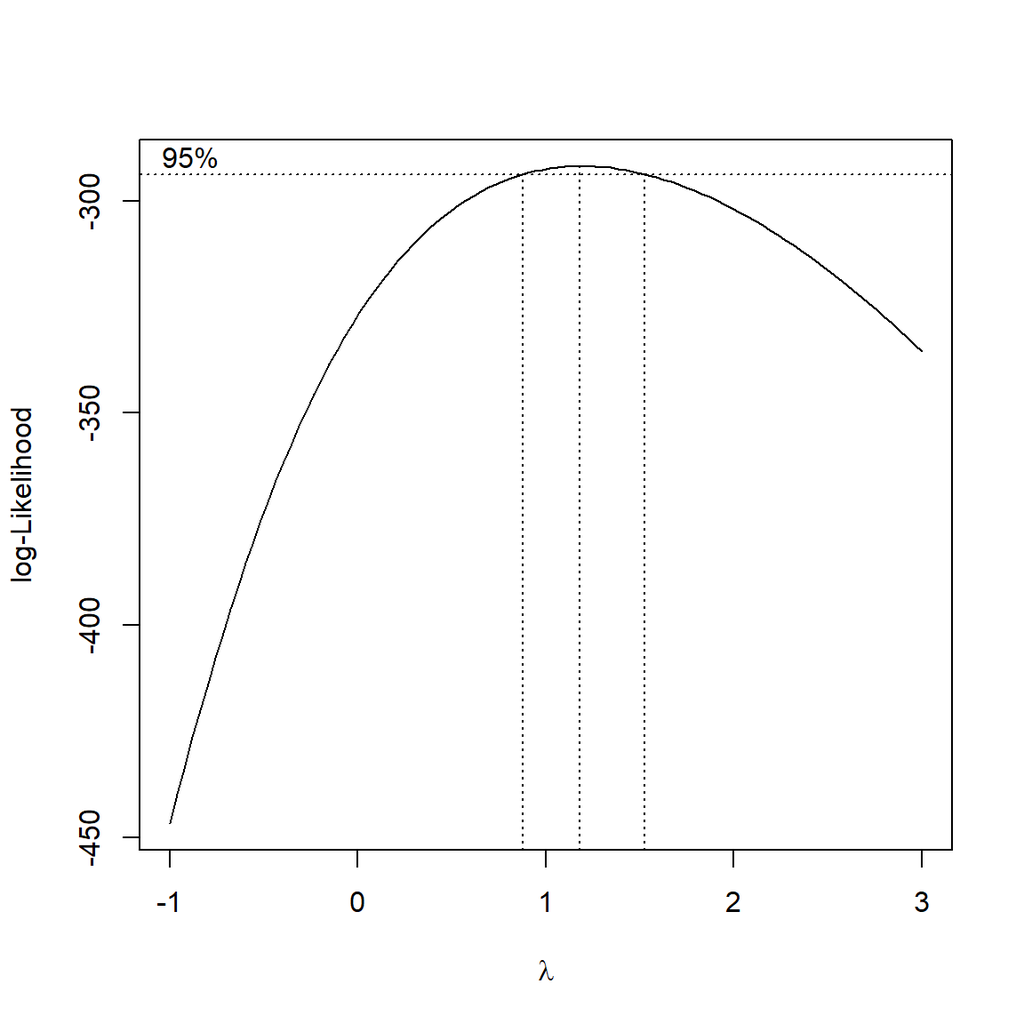

Setelah selesai melakukan transformasi *Box-Cox*, data latih sudah stasioner ragam, karena nilai 1 sudah masuk ke dalam selang 95%. Selanjutnya akan dilakukan *differencing* pada komponen *seasonal* data latih.

# Penanganan Rataan Seasonal

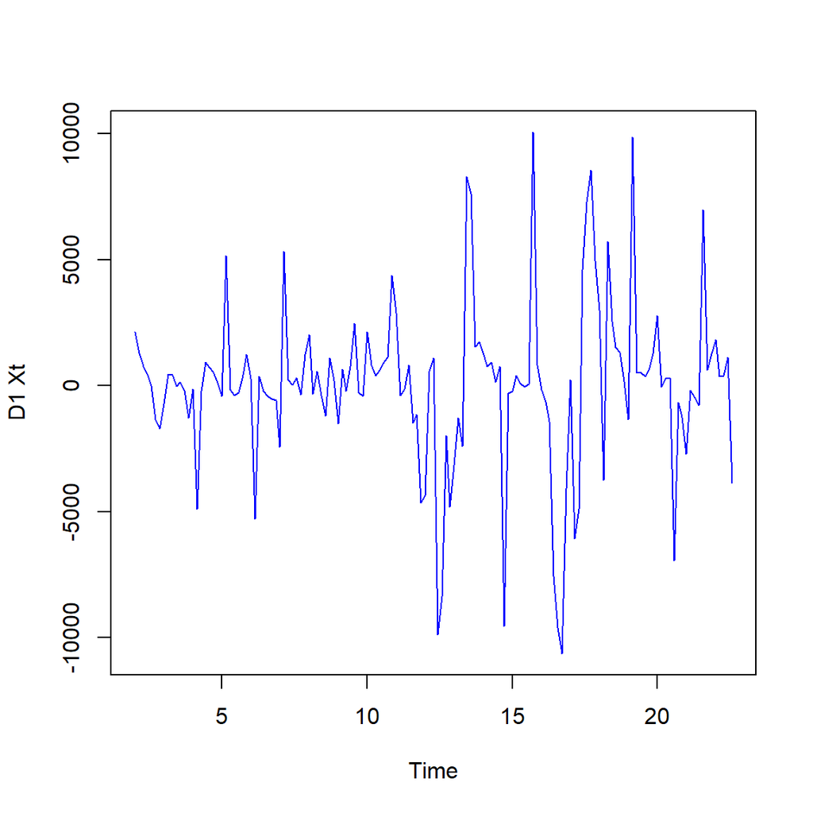

```r
diffbcmrt <- diff(mrtlatts,7)
ts.plot(diffbcmrt, type="l", ylab="D1 Xt", col="blue")
```

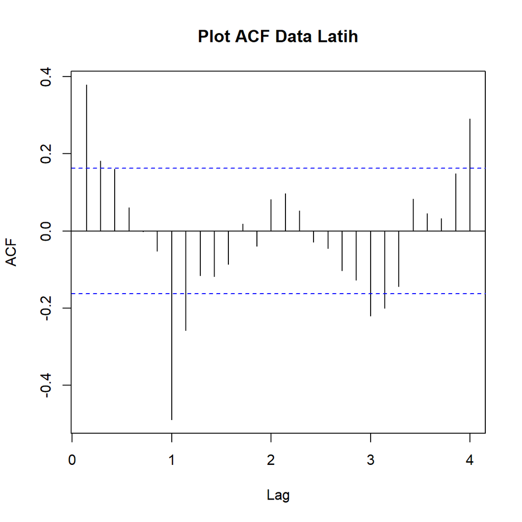

```r
acfD=acf(diffbcmrt, lag.max = 28, xaxt="n", main="Plot ACF Data Latih")
axis(1, at=0:28, labels=0:28)
```

Komponen *Seasonal* pada data latih sudah stasioner dalam rataan. Langkah selanjutnya adalah pendugaan parameter tentatif.

# Identifikasi Model

## Plot ACF

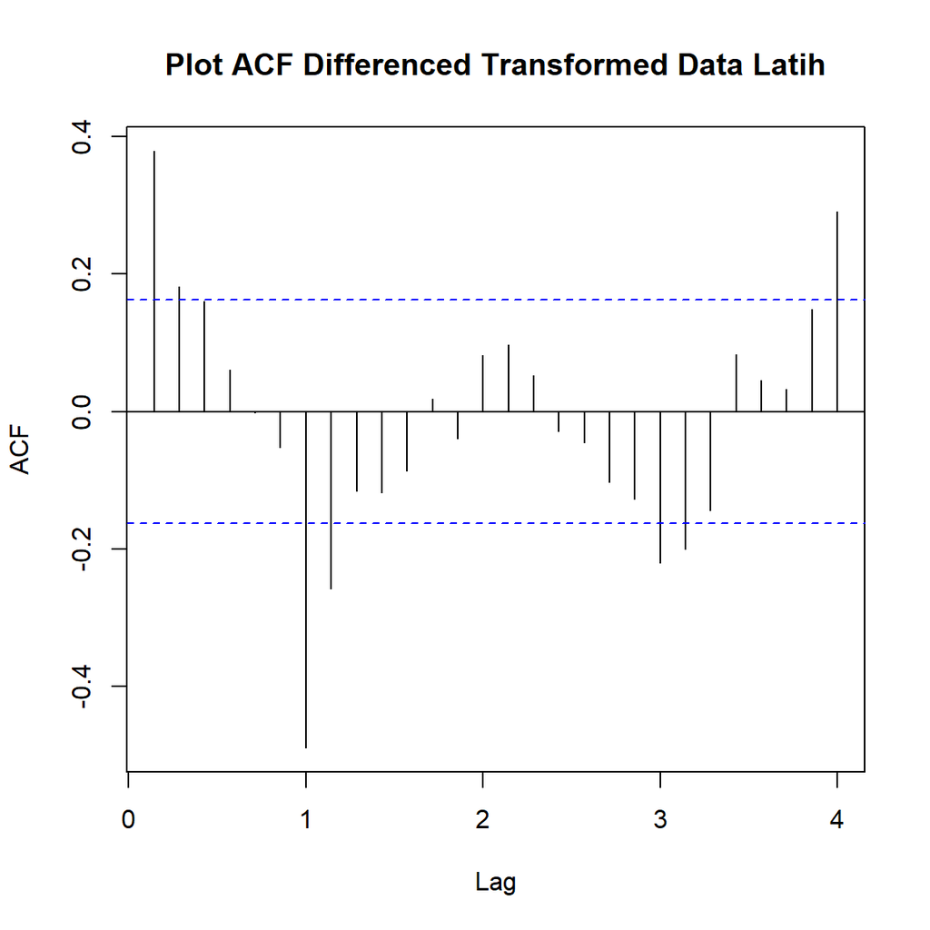

```r
acfD=acf(diffbcmrt, lag.max = 28, xaxt="n", main="Plot ACF Differenced Transformed Data Latih")
axis(1, at=0:28, labels=0:28)
```

Berdasarkan plot ACF di atas, komponen non-*seasonal cuts of* pada lag 2(q=2), sedangkan komponen *seasonal cuts of* pada lag 1(Q=1).

## Plot PACF

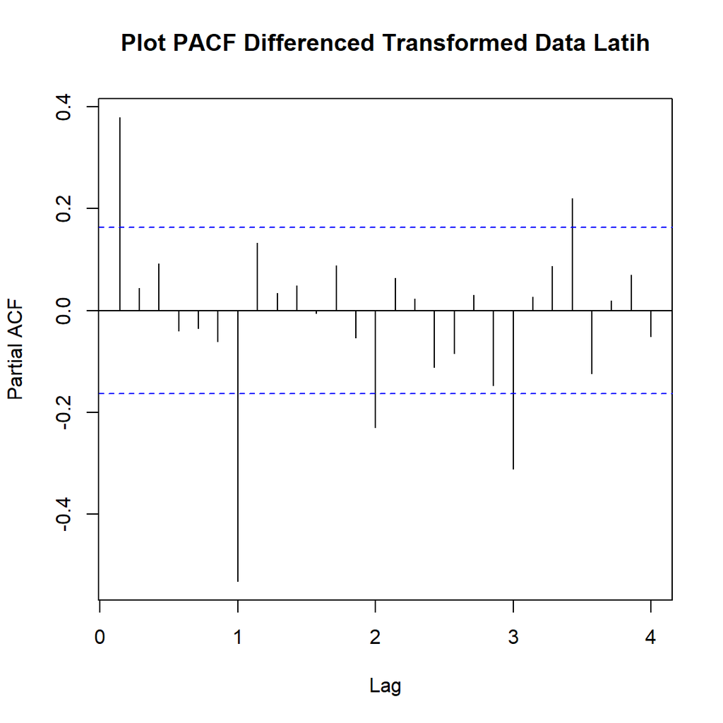

```r
pacfD=pacf(diffbcmrt, lag.max = 28, xaxt="n", main="Plot PACF Differenced Transformed Data Latih")
axis(1, at=0:28, labels=0:28)
```

Plot PACF menunjukkan bahwa komponen non-*seasonal cuts of* pada lag 1(p=1) dan komponen *seasonal tails of* (P=0).

Berdasarkan plot ACF dan PACF, model tentatif yang terbentuk adalah $ARIMA(0,0,2)\times(0,1,1)_{7}$, $ARIMA(1,0,0)\times(0,1,1)_{7}$, $ARIMA(1,0,2)\times(0,1,1)_{7}$.

## Plot EACF

```r
TSA::eacf(diffbcmrt)
```

```
## AR/MA
##   0 1 2 3 4 5 6 7 8 9 10 11 12 13
## 0 x x o o o o x x o o o  o  o  o
## 1 o o o o o o x o o o o  o  o  o
## 2 x x o o o o x o o o o  o  o  o
## 3 x x x o o o x o x o o  o  o  o
## 4 x o o o o o x o x o o  o  o  o
## 5 x o o x o o x x o o o  o  o  o
## 6 o o o x o x x x o x o  o  o  o
## 7 x o o o x o x o o x o  o  o  o
```

Berdasarkan plot EACF di atas, model tentatif yang dapat terbentuk lagi adalah $ARIMA(1,0,1)\times(0,1,1)_{7}$, $ARIMA(2,0,2)\times(0,1,1)_{7}$, $ARIMA(1,0,3)\times(0,1,1)_{7}$.

# Pendugaan Parameter Tentatif

## ARIMA(0,0,2)(0,1,1)[7]

```r
mod1 = Arima(mrtlattsbc,order=c(0,0,2),seasonal=c(0,1,1))
summary(mod1)
```

```
## Series: mrtlattsbc
## ARIMA(0,0,2)(0,1,1)[7]
##
## Coefficients:
##          ma1     ma2     sma1
##       0.4199  0.1435  -0.9442
## s.e.  0.0830  0.0776   0.1222
##
## sigma^2 = 5.487e+14:  log likelihood = -2672.34
## AIC=5352.68   AICc=5352.97   BIC=5364.59
##
## Training set error measures:
##                    ME     RMSE      MAE       MPE     MAPE      MASE       ACF1
## Training set -1224538 22640584 14305654 -32.20676 46.67594 0.6615566 0.02354751
```

```r
lmtest::coeftest(mod1)
```

```
##
## z test of coefficients:
##
##       Estimate Std. Error z value  Pr(>|z|)
## ma1   0.419938   0.083018  5.0584 4.227e-07 ***
## ma2   0.143544   0.077633  1.8490   0.06446 .
## sma1 -0.944224   0.122214 -7.7260 1.110e-14 ***
## ---
## Signif. codes:  0 '***' 0.001 '**' 0.01 '*' 0.05 '.' 0.1 ' ' 1
```

## ARIMA(1,0,0)(0,1,1)[7]

```r
mod2 = Arima(mrtlattsbc,order=c(1,0,0),seasonal=c(0,1,1))
summary(mod2)
```

```
## Series: mrtlattsbc
## ARIMA(1,0,0)(0,1,1)[7]
##
## Coefficients:
##          ar1     sma1
##       0.4619  -0.9465
## s.e.  0.0740   0.1230
##
## sigma^2 = 5.309e+14:  log likelihood = -2670.59
## AIC=5347.19   AICc=5347.36   BIC=5356.12
##
## Training set error measures:
##                    ME     RMSE      MAE       MPE     MAPE      MASE
## Training set -1035650 22349506 13872738 -29.16421 43.77336 0.6415366
##                     ACF1
## Training set -0.03341449
```

```r
lmtest::coeftest(mod2)
```

```
##
## z test of coefficients:
##
##       Estimate Std. Error z value  Pr(>|z|)
## ar1   0.461866   0.074033  6.2387 4.413e-10 ***
## sma1 -0.946476   0.123020 -7.6937 1.430e-14 ***
## ---
## Signif. codes:  0 '***' 0.001 '**' 0.01 '*' 0.05 '.' 0.1 ' ' 1
```

## ARIMA(1,0,2)(0,1,1)[7]

```r
mod3 = Arima(mrtlattsbc,order=c(1,0,2),seasonal=c(0,1,1))
summary(mod3)
```

```
## Series: mrtlattsbc
## ARIMA(1,0,2)(0,1,1)[7]
##
## Coefficients:
##          ar1      ma1      ma2     sma1
##       0.8629  -0.4518  -0.1582  -0.9605
## s.e.  0.0977   0.1288   0.1018   0.1542
##
## sigma^2 = 5.203e+14:  log likelihood = -2668.52
## AIC=5347.04   AICc=5347.47   BIC=5361.92
##
## Training set error measures:
##                     ME     RMSE      MAE       MPE     MAPE      MASE
## Training set -596520.8 21968754 13763204 -27.06753 43.56445 0.6364713
##                      ACF1
## Training set -0.003083762
```

```r
lmtest::coeftest(mod3)
```

```
##
## z test of coefficients:
##
##       Estimate Std. Error z value  Pr(>|z|)
## ar1   0.862855   0.097747  8.8274 < 2.2e-16 ***
## ma1  -0.451767   0.128845 -3.5063 0.0004544 ***
## ma2  -0.158166   0.101794 -1.5538 0.1202341
## sma1 -0.960494   0.154197 -6.2290 4.694e-10 ***
## ---
## Signif. codes:  0 '***' 0.001 '**' 0.01 '*' 0.05 '.' 0.1 ' ' 1
```

## ARIMA(1,0,1)(0,1,1)[7]

```r
mod4 = Arima(mrtlattsbc,order=c(1,0,1),seasonal=c(0,1,1))
summary(mod4)
```

```
## Series: mrtlattsbc
## ARIMA(1,0,1)(0,1,1)[7]
##
## Coefficients:
##          ar1      ma1     sma1
##       0.7296  -0.3624  -0.9409
## s.e.  0.1662   0.2428   0.1074
##
## sigma^2 = 5.305e+14:  log likelihood = -2669.69
## AIC=5347.38   AICc=5347.67   BIC=5359.29
##
## Training set error measures:
##                     ME     RMSE      MAE       MPE   MAPE      MASE       ACF1
## Training set -733401.4 22262298 13789577 -27.13022 44.147 0.6376909 0.03564445
```

```r
lmtest::coeftest(mod4)
```

```
##
## z test of coefficients:
##
##      Estimate Std. Error z value  Pr(>|z|)
## ar1   0.72962    0.16621  4.3898 1.134e-05 ***
## ma1  -0.36236    0.24283 -1.4922    0.1356
## sma1 -0.94092    0.10741 -8.7604 < 2.2e-16 ***
## ---
## Signif. codes:  0 '***' 0.001 '**' 0.01 '*' 0.05 '.' 0.1 ' ' 1
```

## ARIMA(2,0,2)(0,1,1)[7]

```r
mod5 = Arima(mrtlattsbc,order=c(2,0,2),seasonal=c(0,1,1))
summary(mod4)
```

[output not shown]

```r
lmtest::coeftest(mod5)
```

```
##
## z test of coefficients:
##
##      Estimate Std. Error z value  Pr(>|z|)
## ar1   0.64568    0.58073  1.1119    0.2662
## ar2   0.17430    0.44917  0.3880    0.6980
## ma1  -0.23922    0.56630 -0.4224    0.6727
## ma2  -0.25643    0.25251 -1.0155    0.3099
## sma1 -0.95236    0.13103 -7.2682 3.642e-13 ***
## ---
## Signif. codes:  0 '***' 0.001 '**' 0.01 '*' 0.05 '.' 0.1 ' ' 1
```

## ARIMA(1,0,3)(0,1,1)[7]

```r
mod6 = Arima(mrtlattsbc,order=c(1,0,3),seasonal=c(0,1,1))
summary(mod6)
```

```
## Series: mrtlattsbc
## ARIMA(1,0,3)(0,1,1)[7]
##
## Coefficients:
##          ar1      ma1      ma2     ma3     sma1
##       0.8458  -0.4403  -0.1653  0.0358  -0.9502
## s.e.  0.1139   0.1366   0.1019  0.0983   0.1272
##
## sigma^2 = 5.271e+14:  log likelihood = -2668.46
## AIC=5348.91   AICc=5349.52   BIC=5366.77
##
## Training set error measures:
##                     ME     RMSE      MAE       MPE     MAPE     MASE
## Training set -584890.9 22034251 13846127 -27.10253 43.96461 0.640306
##                     ACF1
## Training set 0.001296437
```

```r
lmtest::coeftest(mod6)
```

```
##
## z test of coefficients:
##
##       Estimate Std. Error z value  Pr(>|z|)
## ar1   0.845840   0.113889  7.4269 1.112e-13 ***
## ma1  -0.440274   0.136600 -3.2231  0.001268 **
## ma2  -0.165289   0.101851 -1.6229  0.104621
## ma3   0.035792   0.098287  0.3642  0.715737
## sma1 -0.950162   0.127235 -7.4678 8.156e-14 ***
## ---
## Signif. codes:  0 '***' 0.001 '**' 0.01 '*' 0.05 '.' 0.1 ' ' 1
```

## Perbandingan Model

```r
nilaiAIC <- c(mod1$aic, mod2$aic)
Model.Tentatif <- c("SARIMA(0,0,2)(0,1,1)7", "SARIMA(1,0,0)(0,1,1)7")
PerbandinganModel <- cbind(Model.Tentatif, nilaiAIC)
colnames(PerbandinganModel) <- c("Model Tentatif", "Nilai AIC")
PerbandinganModel <- as.data.frame(PerbandinganModel)
PerbandinganModel
```

```
##          Model Tentatif        Nilai AIC
## 1 SARIMA(0,0,2)(0,1,1)7 5352.68086081211
## 2 SARIMA(1,0,0)(0,1,1)7 5347.18798384058
```

Model yang akan digunakan adalah model SARIMA(1,0,0)(0,1,1)7.

# Overfitting Modelt Tentatif Terbaik

Akan dilakukan *overfit* untuk model SARIMA(1,0,0)(0,1,1)7 pada komponden p, q, P, dan Q. Didapat model *overfit*nya adalah SARIMA(2,0,0)(0,1,1)7, SARIMA(1,0,1)(0,1,1)7, SARIMA(1,0,0)(1,1,1)7, dan SARIMA(1,0,0)(0,1,2)7

```r
overfit1 = Arima(mrtlattsbc,order=c(2,0,0),seasonal=c(0,1,1))
summary(overfit1)
```

```
## Series: mrtlattsbc
## ARIMA(2,0,0)(0,1,1)[7]
##
## Coefficients:
##          ar1     ar2     sma1
##       0.4264  0.0757  -0.9464
## s.e.  0.0836  0.0841   0.1201
##
## sigma^2 = 5.318e+14:  log likelihood = -2670.19
## AIC=5348.38   AICc=5348.67   BIC=5360.29
##
## Training set error measures:
##                     ME     RMSE      MAE      MPE     MAPE      MASE
## Training set -942884.3 22288678 13769606 -28.2082 43.70413 0.6367674
##                      ACF1
## Training set -0.008043481
```

```r
lmtest::coeftest(overfit1)
```

```
##
## z test of coefficients:
##
##       Estimate Std. Error z value  Pr(>|z|)
## ar1   0.426428   0.083643  5.0982 3.430e-07 ***
## ar2   0.075695   0.084125  0.8998    0.3682
## sma1 -0.946440   0.120103 -7.8803 3.267e-15 ***
## ---
## Signif. codes:  0 '***' 0.001 '**' 0.01 '*' 0.05 '.' 0.1 ' ' 1
```

```r
overfit2 = Arima(mrtlattsbc,order=c(1,0,1),seasonal=c(0,1,1))
summary(overfit2)
```

```
## Series: mrtlattsbc
## ARIMA(1,0,1)(0,1,1)[7]
##
## Coefficients:
##          ar1      ma1     sma1
##       0.7296  -0.3624  -0.9409
## s.e.  0.1662   0.2428   0.1074
##
## sigma^2 = 5.305e+14:  log likelihood = -2669.69
## AIC=5347.38   AICc=5347.67   BIC=5359.29
##
## Training set error measures:
##                     ME     RMSE      MAE       MPE   MAPE      MASE       ACF1
## Training set -733401.4 22262298 13789577 -27.13022 44.147 0.6376909 0.03564445
```

```r
lmtest::coeftest(overfit2)
```

```
##
## z test of coefficients:
##
##      Estimate Std. Error z value  Pr(>|z|)
## ar1   0.72962    0.16621  4.3898 1.134e-05 ***
## ma1  -0.36236    0.24283 -1.4922    0.1356
## sma1 -0.94092    0.10741 -8.7604 < 2.2e-16 ***
## ---
## Signif. codes:  0 '***' 0.001 '**' 0.01 '*' 0.05 '.' 0.1 ' ' 1
```

```r
overfit3 = Arima(mrtlattsbc,order=c(1,0,0),seasonal=c(1,1,1))
summary(overfit3)
```

```
## Series: mrtlattsbc
## ARIMA(1,0,0)(1,1,1)[7]
##
## Coefficients:
##          ar1    sar1     sma1
##       0.4606  0.0094  -0.9533
## s.e.  0.0754  0.0992   0.1561
##
## sigma^2 = 5.326e+14:  log likelihood = -2670.59
## AIC=5349.18   AICc=5349.46   BIC=5361.09
##
## Training set error measures:
##                    ME     RMSE      MAE       MPE     MAPE      MASE
## Training set -1047826 22307051 13854372 -29.12642 43.70013 0.6406873
##                     ACF1
## Training set -0.03283352
```

```r
lmtest::coeftest(overfit3)
```

```
##
## z test of coefficients:
##
##       Estimate Std. Error z value  Pr(>|z|)
## ar1   0.460580   0.075401  6.1084 1.006e-09 ***
## sar1  0.009411   0.099213  0.0949    0.9244
## sma1 -0.953311   0.156105 -6.1069 1.016e-09 ***
## ---
## Signif. codes:  0 '***' 0.001 '**' 0.01 '*' 0.05 '.' 0.1 ' ' 1
```

```r
overfit4 = Arima(mrtlattsbc,order=c(1,0,0),seasonal=c(0,1,2))
summary(overfit4)
```

```
## Series: mrtlattsbc
## ARIMA(1,0,0)(0,1,2)[7]
##
## Coefficients:
##          ar1     sma1     sma2
##       0.4609  -0.9443  -0.0072
## s.e.  0.0751   0.1354   0.0849
##
## sigma^2 = 5.331e+14:  log likelihood = -2670.59
## AIC=5349.18   AICc=5349.47   BIC=5361.09
##
## Training set error measures:
##                    ME     RMSE      MAE       MPE     MAPE      MASE
## Training set -1045501 22316003 13858480 -29.13387 43.71534 0.6408773
##                     ACF1
## Training set -0.03298364
```

```r
lmtest::coeftest(overfit4)
```

```
##
## z test of coefficients:
##
##        Estimate Std. Error z value  Pr(>|z|)
## ar1   0.4608590  0.0751395  6.1334 8.603e-10 ***
## sma1 -0.9443058  0.1353810 -6.9752 3.055e-12 ***
## sma2 -0.0072455  0.0849428 -0.0853     0.932
## ---
## Signif. codes:  0 '***' 0.001 '**' 0.01 '*' 0.05 '.' 0.1 ' ' 1
```

Dari semua model *overfit* yang dibuat, tidak ada model yang semua parameternya signifikan, maka akan dilanjutkan dengan model SARIMA(1,0,0)(0,1,1)7.

# Analisis Sisaan

```r
modelfix <- Arima(mrtlattsbc,order=c(1,0,0),seasonal=c(0,1,1))


sisaan.model <- modelfix$residuals
par(mfrow=c(2,2))
car::qqPlot(sisaan.model)
```

```
## [1] 81 97
```

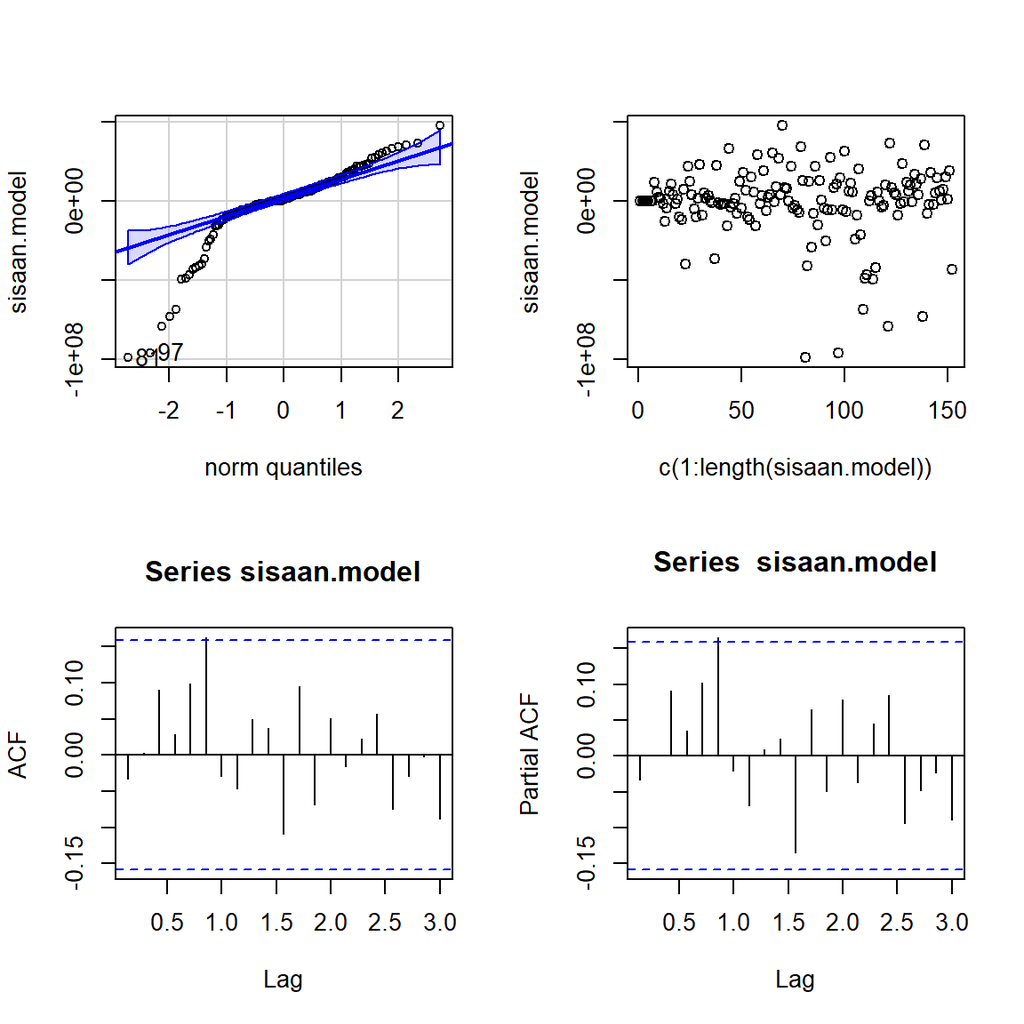

```r
plot(c(1:length(sisaan.model)),sisaan.model)
acf(sisaan.model)
pacf(sisaan.model)
```

```r
par(mfrow = c(1,1))
```

Dari eksplorasi plot di atas, sisaanya model tidak menyebar normal, kemudian ragam dari sisaanya cenderung tidak homogen, dari plot ACF dan PACF terdapat lag yang signifikan, artinya mungkin terdapat autokorelasi pada sisaan. Perlu dilakukan uji formal untuk memvalidasi kesimpulan dari eksplorasi plot di atas.

## Uji Formal Sisaan Model

### Normalitas Sisaan

```r
ks.test(sisaan.model,"pnorm")
```

```
##
##  Asymptotic one-sample Kolmogorov-Smirnov test
##
## data:  sisaan.model
## D = 0.57895, p-value < 2.2e-16
## alternative hypothesis: two-sided
```

```r
shapiro.test(sisaan.model)
```

```
##
##  Shapiro-Wilk normality test
##
## data:  sisaan.model
## W = 0.83588, p-value = 9.274e-12
```

```r
nortest::ad.test(sisaan.model)
```

```
##
##  Anderson-Darling normality test
##
## data:  sisaan.model
## A = 7.4961, p-value < 2.2e-16
```

$H_0$ : Sisaan menyebar normal

$H_1$ : Sisaan tidak menyebar normal

Setelah melakukan 3 uji normalitas, ketiga uji menghasilkan kesimpulan yang sama, yakni sisaan tidak menyebar normal. Hal ini sama seperti eksplorasi yang dilakukan.

### Autokorelasi

```r
Box.test(sisaan.model, type = "Ljung")
```

```
##
##  Box-Ljung test
##
## data:  sisaan.model
## X-squared = 0.17308, df = 1, p-value = 0.6774
```

$H_0$ : Sisaan saling bebas

$H_1$ : Sisaan tidak tidak saling bebas

Uji Ljung-Box menghasilkan nilai *p-value* sebesar 0.6774, yang mana lebih besar dari 0.05. Maka tak tolak H0, artinya pada tingkat kepercayaan 95%, dapat dinyatakan bahwa tidak ada autokorelasi pada sisaan model. Hal ini berbeda dengan eksplorasi yang dilakukan.

```r
Box.test((sisaan.model)^2, type = "Ljung")
```

```
##
##  Box-Ljung test
##
## data:  (sisaan.model)^2
## X-squared = 1.5905, df = 1, p-value = 0.2073
```

$H_0$ : Ragam sisaan homogen

$H_1$ : Ragam sisaan tidak homogen

Berdasarkan uji Ljung-Box terhadap sisaan kuadrat, didapat *p-value* sebesar 0.2073 yang lebih besar dari 0.05. Maka tak tolak H0, artinya pada tingkat kepercayaan 95%, dapat dinyatakan bahwa ragam sisaan homogen. Hal ini berbeda dari eksplorasi yang dilakukan.

```r
t.test(sisaan.model, mu = 0, conf.level = 0.95)
```

```
##
##  One Sample t-test
##
## data:  sisaan.model
## t = -0.57003, df = 151, p-value = 0.5695
## alternative hypothesis: true mean is not equal to 0
## 95 percent confidence interval:
##  -4625327  2554028
## sample estimates:
## mean of x
##  -1035650
```

$H_0$ : nilai tengah sisaan sama dengan 0

$H_1$ : nilai tengah sisaan tidak sama dengan 0

Berdasarkan uji t yang dilakukan, didapat nilai *p-value* sebesar 0.5695, yang mana lebih besar dari 0.05. Maka tak tolak H0, artinya pada tingkat 95%, dapat dinyatakan bahwa nilai tengah sisaan = 0.

# Peramalan

```r
ramal.sarima = forecast::forecast(modelfix, h=45)
ramal.sarima
```

```
##          Point Forecast    Lo 80     Hi 80     Lo 95     Hi 95
## 22.71429       74549051 44851176 104246926  29130070 119968031
## 22.85714       35547642  2838778  68256507 -14476249  85571534
## 23.00000       27562084 -5737354  60861523 -23365012  78489181
## 23.14286       85026941 51599524 118454358  33904118 136149764
## 23.28571      102836514 69381866 136291161  51672045 154000982
## 23.42857      101082390 67621966 134542814  49909087 152255692
## 23.57143       88596916 55135400 122058432  37421943 139771889
## 23.71429       88537928 55014977 122060879  37268999 139806857
## 23.85714       42008635  8476096  75541173  -9274957  93292226
## 24.00000       30546199 -2971958  64064356 -20715398  81807797
## 24.14286       86405204 52886467 119923940  35142720 137667687
## 24.28571      103473087 69954233 136991940  52210423 154735750
## 24.42857      101376401 67857553 134895250  50113746 152639057
## 24.57143       88732710 55214002 122251419  37470270 139995151
## 24.71429       88600647 55027919 122173375  37255590 139945703
## 24.85714       42037602  8456860  75618344  -9319711  93394915
## 25.00000       30559578 -3006470  64125627 -20775263  81894420
## 25.14286       86411383 52844826 119977941  35075763 137747003
## 25.28571      103475941 69909281 137042600  52140164 154811717
## 25.42857      101377720 67811068 134944371  50041956 152713484
## 25.57143       88733319 55166809 122299830  37397771 140068867
## 25.71429       88600928 54980506 122221350  37182930 140018926
## 25.85714       42037732  8409314  75666150  -9392495  93467959
## 26.00000       30559638 -3054105  64173382 -20848146  81967423
## 26.14286       86411411 52797159 120025662  35002849 137819972
## 26.28571      103475953 69861600 137090307  52067236 154884671
## 26.42857      101377726 67763380 134992071  49969020 152786431
## 26.57143       88733322 55119117 122347527  37324832 140141812
## 26.71429       88600929 54932890 122268969  37110106 140091752
## 26.85714       42037733  8361709  75713757  -9465302  93540767
## 27.00000       30559639 -3101732  64221009 -20920985  82040263
## 27.14286       86411411 52749533 120073289  34930011 137892811
## 27.28571      103475953 69813974 137137933  51994398 154957509
## 27.42857      101377726 67715754 135039697  49896182 152859269
## 27.57143       88733322 55071491 122395153  37251994 140214650
## 27.71429       88600929 54885340 122316519  37037385 140164474
## 27.85714       42037733  8314170  75761296  -9538006  93613472
## 28.00000       30559639 -3149292  64268569 -20993722  82112999
## 28.14286       86411411 52701974 120120848  34857276 137965546
## 28.28571      103475953 69766415 137185492  51921663 155030244
## 28.42857      101377726 67668195 135087256  49823447 152932004
## 28.57143       88733322 55023932 122442712  37179258 140287385
## 28.71429       88600929 54837856 122364002  36964765 140237094
## 28.85714       42037733  8266697  75808768  -9610609  93686074
## 29.00000       30559639 -3196784  64316062 -21066355  82185633
```

# Transformasi Balik

```r
Hasilngedukun=InvBoxCox(ramal.sarima$mean, 2)
```

# Akurasi Data Latih

```r
accuracy(sqrt(modelfix$fitted),mrtlat)
```

```
##                ME     RMSE      MAE      MPE     MAPE      ACF1 Theil's U
## Test set 3637.753 3710.401 3637.753 29.69232 29.69232 0.3565657  1.446015
```

# Akurasi Data Uji

```r
accuracy(Hasilngedukun,mrtuji)
```

```
##                 ME     RMSE      MAE       MPE     MAPE     ACF1 Theil's U
## Test set -924.2286 4954.311 4112.275 -21.80867 42.40891 0.378252  1.080445
```

Didapat nilai **MAPE** untuk data latih adalah sebesar 29.69, sedangkan nilai **MAPE** data uji adalah sebesari 42.4, yang mana kedua nilai **MAPE** ini jatuh ke dalam kategori layak(20-50)